# Actividad Económica de Córdoba

Parte 2

Aqúi se presentan de los cruces de los puntos 4, 6 y 8 del [documento](https://docs.google.com/document/d/1RtC2ry0b8YD-Nq7izZqeMDCWeth3iZRV/edit?usp=sharing&ouid=118147297537494615439&rtpof=true&sd=true)

## P29: ¿En cuál de estos perfiles ha tenido mayor dificultad para cubrir vacantes durante 2022?

Esta pregunta constituye 7 variables, una por cada tipo de de puesto én el que la empresa tuvo dificultad:

- Gerentes, directores y altos funcionarios
- Puestos administrativos y secretariales
- Operarios de procesos, plantas y máquinas
- Puestos de ventas y atención al cliente
- Puestos profesionales y técnicos
- Otros puestos con oficios calificados
- Otros puestos de oficios no calificados

A continuación se presentan cruces de estas variables con algunas otras, de tamaño o perfil. En cada caso se expondrá la proporción de empresas que manifestaron tener dificultades para conseguir cubrir vacantes en cada tipo de perfil, en cada una de las categorías de la variable con la que se está cruzando.

Se intrepretan algunos valores de la primera tabla fines orientativos, pero el resto se realiza de manera análoga.

### A. versus tamaño de empresa

Ver definición de tamaño en [Reporte General](https://pabort.github.io/AEC-reporte/reporte_gral#Bloque_0_Distribuci%C3%B3n_de_empresas_por_tama%C3%B1o)

- 5,13% de las empresas de la categoría Micro tuvieron dificultades para cubrir puestos de Gerentes-Directores, mientras que el 8,33% de las Pequeñas tuvieron problemas cubrir este perfil, y el 20% de las Mediana-Grandes
- 48,72% de Las empresas Micro manifestaron tener dificultades para cubrir puestos de Operarios, mientras que el 41,67% y 32% de las Pequeñas y Medianas-Grandes, respectivamente, manifestaron esta dificultad.

| Puesto | Micro | Pequeña | Mediana-Grande |
| --- | --- | --- | --- |
| Gerentes-directores | 5.13 % | 8.33 % | 20.00 % |
| Administrativos | 20.51 % | 20.83 % | 12.00 % |
| Operarios | 48.72 % | 41.67 % | 32.00 % |
| Ventas-atención | 15.38 % | 27.08 % | 12.00 % |
| Profesionales-técnicos | 48.72 % | 41.67 % | 64.00 % |
| Otros puestos calificados | 23.08 % | 33.33 % | 44.00 % |
| Otros puestos no calificados | 15.38 % | 4.17 % | 4.00 % |

Estos porcentajes se calculan sobre los siguientes tamaños de muestras en cada categoría

| tamanio | cantidad |
| --- | --- |
| Mediana-Grande | 25 |
| Micro | 39 |
| Pequeña | 48 |

### B. versus nivel educativo

Ver definición categorías de nivel educativo en [Reporte Cruces Parte 1](https://pabort.github.io/AEC-reporte/crucesAEC/reporte_cruces_AEC.html#p18-del-total-de-personal-en-relaci%C3%B3n-de-dependencia-indique-la-cantidad-seg%C3%BAn-nivel-educativo):

- `Nivel 1`: Porcentaje mayoritario en pesonal con hasta secundario incompleto (es decir, agregando `G04Q18[SQ001]` a `G04Q18[SQ004]`)
- `Nivel 2`: Porcentaje mayoritario en pesonal con secundario completo (es decir, `G04Q18[SQ005]`)
- `Nivel 3`: Porcentaje mayoritario en pesonal con estudios terciarios/universitarios completos o incompletos (es decir, agregando `G04Q18[SQ006]` a `G04Q18[SQ007]`)

| Puesto | Nivel 1 | Nivel 2 | Nivel 3 |
| --- | --- | --- | --- |
| Gerentes-directores | 15.79 % | 11.54 % | 5.56 % |
| Administrativos | 10.53 % | 28.85 % | 8.33 % |
| Operarios | 52.63 % | 51.92 % | 22.22 % |
| Ventas-atención | 31.58 % | 21.15 % | 8.33 % |
| Profesionales-técnicos | 31.58 % | 34.62 % | 80.56 % |
| Otros puestos calificados | 21.05 % | 42.31 % | 27.78 % |
| Otros puestos no calificados | 10.53 % | 5.77 % | 8.33 % |

Estos porcentajes se calculan sobre los siguientes tamaños de muestras en cada categoría

| nivelEducCat | n |
| --- | --- |
| Nivel 1 | 19 |
| Nivel 2 | 52 |
| Nivel 3 | 36 |
| NA | 5 |

*No se considera para el cálculo de porcentajes `NA` o `No sabe / No responde`*

### C. versus P12: ¿Posee la empresa/organización un área específica de “recursos humanos/administración de personal”?

| Puesto | Con área de RRHH | Sin área de RRHH |
| --- | --- | --- |
| Gerentes-directores | 14.71 % | 2.38 % |
| Administrativos | 16.18 % | 21.43 % |
| Operarios | 41.18 % | 42.86 % |
| Ventas-atención | 22.06 % | 16.67 % |
| Profesionales-técnicos | 47.06 % | 50.00 % |
| Otros puestos calificados | 33.82 % | 26.19 % |
| Otros puestos no calificados | 5.88 % | 11.90 % |

Estos porcentajes se calculan sobre los siguientes tamaños de muestras en cada categoría

| Tiene área RRHH | n |
| --- | --- |
| No | 42 |
| No sabe / No responde | 1 |
| Sí | 68 |
| NA | 1 |

*No se considera para el cálculo de porcentajes `NA` o `No sabe / No responde`*

### D. versus P11: Porcentaje de Exportaciones sobre el total facturado en el año 2021

En este caso se cateorizó la variable, de forma que si es igual a 0, se considera que no exporta, y cuando es mayor a 0 que sí exporta.

| Puesto | Sí exporta | No exporta |
| --- | --- | --- |
| Gerentes-directores | 11.43 % | 8.33 % |
| Administrativos | 5.71 % | 25.00 % |
| Operarios | 48.57 % | 40.28 % |
| Ventas-atención | 11.43 % | 22.22 % |
| Profesionales-técnicos | 68.57 % | 41.67 % |
| Otros puestos calificados | 28.57 % | 33.33 % |
| Otros puestos no calificados | 5.71 % | 9.72 % |

Estos porcentajes se calculan sobre los siguientes tamaños de muestras en cada categoría

| Exporta | n |
| --- | --- |
| No exporta | 72 |
| Sí exporta | 35 |
| NA | 5 |

*No se considera para el cálculo de porcentajes `NA` o `No sabe / No responde`*

## P30: ¿Cuáles considera son las principales dificultades para cubrir dichos puestos?

Esta pregunta constituye 10 variables, una por cada tipo de dificultad que se puede considerar:

- ‘Falta de postulantes’,
- ‘Competencia con otros empleadores’,
- ‘Pretensiones salariales mayores a las ofrecidas’,
- ‘Localización del puesto laboral’,
- ‘Falta de experiencia’,
- ‘Postulantes sin el nivel educativo mínimo esperado’,
- ‘Falta de competencias técnicas’,
- ‘Falta de competencias socioemocionales’,
- ‘Postulantes sobrecalificados para el puesto’,
- ‘Otras’

### A. versus P29: En cuál de estos perfiles ha tenido mayor dificultad para cubrir vacantes durante 2022?

- 45.45% de las empresas que manifestaron tener dificultades para cubrir perfiles de Gerentes-Directivos, esgrimieron que la “falta de postulantes” era una de las causas.
- 53.19% de las empresas que manifestaron tener dificultades para cubrir perfiles de Operarios, esgrimieron que la “falta de postulantes” era una de las causas.
- 49.09% de las empresas que manifestaron tener dificultades para cubrir perfiles de “Profesionales”, esgrimieron que las “Pretensiones salariales mayores a las ofrecidas” era una de las causas.

| Dificultad | Gerentes-directores | Administrativos | Operarios | Ventas | Prefesionales | Otros calif. | Otros no calif. |
| --- | --- | --- | --- | --- | --- | --- | --- |
| Falta de postulantes | 45.45 % | 38.10 % | 53.19 % | 31.82 % | 45.45 % | 58.33 % | 33.33 % |
| Competencia con otros empleadores | 18.18 % | 14.29 % | 19.15 % | 9.09 % | 30.91 % | 25.00 % | 22.22 % |
| Pretensiones salariales mayores a las ofrecidas | 36.36 % | 42.86 % | 29.79 % | 36.36 % | 49.09 % | 41.67 % | 22.22 % |
| Localización del puesto laboral | 9.09 % | 14.29 % | 10.64 % | 22.73 % | 7.27 % | 16.67 % | 11.11 % |
| Falta de experiencia | 45.45 % | 52.38 % | 55.32 % | 50.00 % | 38.18 % | 50.00 % | 22.22 % |
| Postulantes sin el nivel educativo mínimo esperado | 27.27 % | 14.29 % | 21.28 % | 13.64 % | 20.00 % | 19.44 % | 22.22 % |
| Falta de competencias técnicas | 27.27 % | 33.33 % | 46.81 % | 45.45 % | 41.82 % | 41.67 % | 22.22 % |
| Falta de competencias socioemocionales | 27.27 % | 9.52 % | 6.38 % | 9.09 % | 10.91 % | 5.56 % | 22.22 % |
| Postulantes sobrecalificados para el puesto | 9.09 % | 0.00 % | 0.00 % | 0.00 % | 0.00 % | 0.00 % | 11.11 % |
| Otras | 0.00 % | 19.05 % | 0.00 % | 9.09 % | 7.27 % | 5.56 % | 33.33 % |

### B. versus tamaño de empresa

Ver definición de tamaño en [Reporte General](https://pabort.github.io/AEC-reporte/reporte_gral#Bloque_0_Distribuci%C3%B3n_de_empresas_por_tama%C3%B1o)

| Dificultad | Micro | Pequeña | Mediana-Grande |
| --- | --- | --- | --- |
| Falta de postulantes | 51.28 % | 43.75 % | 48.00 % |
| Competencia con otros empleadores | 15.38 % | 27.08 % | 36.00 % |
| Pretensiones salariales mayores a las ofrecidas | 38.46 % | 35.42 % | 44.00 % |
| Localización del puesto laboral | 7.69 % | 16.67 % | 8.00 % |
| Falta de experiencia | 48.72 % | 47.92 % | 20.00 % |
| Postulantes sin el nivel educativo mínimo esperado | 17.95 % | 18.75 % | 12.00 % |
| Falta de competencias técnicas | 43.59 % | 29.17 % | 48.00 % |
| Falta de competencias socioemocionales | 7.69 % | 10.42 % | 12.00 % |
| Postulantes sobrecalificados para el puesto | 0.00 % | 0.00 % | 4.00 % |
| Otras | 12.82 % | 4.17 % | 4.00 % |

Estos porcentajes se calculan sobre los siguientes tamaños de muestras en cada categoría

| tamanio | cantidad |
| --- | --- |
| Mediana-Grande | 25 |
| Micro | 39 |
| Pequeña | 48 |

### C. versus nivel educativo

Ver definición categorías de nivel educativo en [Reporte Cruces Parte 1](https://pabort.github.io/AEC-reporte/crucesAEC/reporte_cruces_AEC.html#p18-del-total-de-personal-en-relaci%C3%B3n-de-dependencia-indique-la-cantidad-seg%C3%BAn-nivel-educativo):

- `Nivel 1`: Porcentaje mayoritario en pesonal con hasta secundario incompleto (es decir, agregando `G04Q18[SQ001]` a `G04Q18[SQ004]`)
- `Nivel 2`: Porcentaje mayoritario en pesonal con secundario completo (es decir, `G04Q18[SQ005]`)
- `Nivel 3`: Porcentaje mayoritario en pesonal con estudios terciarios/universitarios completos o incompletos (es decir, agregando `G04Q18[SQ006]` a `G04Q18[SQ007]`)

| Dificultad | Nivel 1 | Nivel 2 | Nivel 3 |
| --- | --- | --- | --- |
| Falta de postulantes | 52.63 % | 48.08 % | 44.44 % |
| Competencia con otros empleadores | 15.79 % | 19.23 % | 36.11 % |
| Pretensiones salariales mayores a las ofrecidas | 31.58 % | 30.77 % | 52.78 % |
| Localización del puesto laboral | 10.53 % | 19.23 % | 2.78 % |
| Falta de experiencia | 42.11 % | 50.00 % | 36.11 % |
| Postulantes sin el nivel educativo mínimo esperado | 21.05 % | 17.31 % | 11.11 % |
| Falta de competencias técnicas | 42.11 % | 36.54 % | 38.89 % |
| Falta de competencias socioemocionales | 15.79 % | 9.62 % | 8.33 % |
| Postulantes sobrecalificados para el puesto | 5.26 % | 0.00 % | 0.00 % |
| Otras | 0.00 % | 3.85 % | 13.89 % |

Estos porcentajes se calculan sobre los siguientes tamaños de muestras en cada categoría

| nivelEducCat | n |
| --- | --- |
| Nivel 1 | 19 |
| Nivel 2 | 52 |
| Nivel 3 | 36 |
| NA | 5 |

*No se considera para el cálculo de porcentajes `NA` o `No sabe / No responde`*

### D. versus P12: ¿Posee la empresa/organización un área específica de “recursos humanos/administración de personal”?

| Dificultad | Con área de RRHH | Sin área de RRHH |
| --- | --- | --- |
| Falta de postulantes | 41.18 % | 57.14 % |
| Competencia con otros empleadores | 27.94 % | 21.43 % |
| Pretensiones salariales mayores a las ofrecidas | 36.76 % | 40.48 % |
| Localización del puesto laboral | 14.71 % | 7.14 % |
| Falta de experiencia | 35.29 % | 50.00 % |
| Postulantes sin el nivel educativo mínimo esperado | 22.06 % | 9.52 % |
| Falta de competencias técnicas | 36.76 % | 38.10 % |
| Falta de competencias socioemocionales | 11.76 % | 7.14 % |
| Postulantes sobrecalificados para el puesto | 1.47 % | 0.00 % |
| Otras | 5.88 % | 9.52 % |

Estos porcentajes se calculan sobre los siguientes tamaños de muestras en cada categoría

| Tiene área RRHH | n |
| --- | --- |
| No | 42 |
| No sabe / No responde | 1 |
| Sí | 68 |
| NA | 1 |

*No se considera para el cálculo de porcentajes `NA` o `No sabe / No responde`*

### E. versus P11: Porcentaje de Exportaciones sobre el total facturado en el año 2021

En este caso se cateorizó la variable, de forma que si es igual a 0, se considera que no exporta, y cuando es mayor a 0 que sí exporta.

| Dificultad | Sí exporta | No exporta |
| --- | --- | --- |
| Falta de postulantes | 51.43 % | 43.06 % |
| Competencia con otros empleadores | 37.14 % | 20.83 % |
| Pretensiones salariales mayores a las ofrecidas | 40.00 % | 37.50 % |
| Localización del puesto laboral | 8.57 % | 13.89 % |
| Falta de experiencia | 37.14 % | 45.83 % |
| Postulantes sin el nivel educativo mínimo esperado | 20.00 % | 16.67 % |
| Falta de competencias técnicas | 31.43 % | 43.06 % |
| Falta de competencias socioemocionales | 17.14 % | 5.56 % |
| Postulantes sobrecalificados para el puesto | 2.86 % | 0.00 % |
| Otras | 2.86 % | 9.72 % |

Estos porcentajes se calculan sobre los siguientes tamaños de muestras en cada categoría

| Exporta | n |
| --- | --- |
| No exporta | 72 |
| Sí exporta | 35 |
| NA | 5 |

*No se considera para el cálculo de porcentajes `NA` o `No sabe / No responde`*

## P37: ¿ Cuáles de estas afirmaciones considera se aproximan mejor a su opinión sobre la capacitación de su personal y la oferta disponible?

Esta pregunta constituye 10 variables, una por cada afirmación:

- No tenemos un diagnóstico preciso de nuestras necesidades de capacitación
- En general, no hay suficientes ofertas de capacitación disponibles
- Las temáticas de las ofertas de capacitación que nos interesan no existen localmente
- La calidad de las ofertas locales no es buena
- Desconozco cuál es la oferta de capacitación disponible
- No contamos con recursos suficientes para invertir en capacitación
- Los empleados no tienen tiempo para dedicar a capacitaciones
- La capacitación no es una prioridad para nosotros
- El personal ya está capacitado
- La principal capacitación es la que hacemos dentro de la empresa/organización

### A. versus tamaño de empresa

Ver definición de tamaño en [Reporte General](https://pabort.github.io/AEC-reporte/reporte_gral#Bloque_0_Distribuci%C3%B3n_de_empresas_por_tama%C3%B1o)

| Afirmación | Micro | Pequeña | Mediana-Grande |
| --- | --- | --- | --- |
| No tenemos un diagnóstico preciso de nuestras necesidades | 16.04 % | 12.00 % | 22.58 % |
| No hay suficientes ofertas de capacitación disponibles | 18.87 % | 14.67 % | 16.13 % |
| Capacitaciones que nos interesan no existen localmente | 12.26 % | 20.00 % | 12.90 % |
| La calidad de las ofertas locales no es buena | 7.55 % | 12.00 % | 6.45 % |
| Desconozco cuál es la oferta de capacitación disponible | 23.58 % | 14.67 % | 6.45 % |
| No contamos con rec. sufic. para invertir en capacitación | 22.64 % | 13.33 % | 9.68 % |
| Empleados no tienen tiempo para dedicar a capacitaciones | 10.38 % | 22.67 % | 32.26 % |
| La capacitación no es una prioridad para nosotros | 11.32 % | 4.00 % | 6.45 % |
| El personal ya está capacitado | 10.38 % | 8.00 % | 6.45 % |
| La principal capacitación es interna | 51.89 % | 58.67 % | 45.16 % |

Estos porcentajes se calculan sobre los siguientes tamaños de muestras en cada categoría

| tamanio | cantidad |
| --- | --- |
| Mediana-Grande | 31 |
| Micro | 106 |
| Pequeña | 75 |

### B. versus nivel educativo

Ver definición categorías de nivel educativo en [Reporte Cruces Parte 1](https://pabort.github.io/AEC-reporte/crucesAEC/reporte_cruces_AEC.html#p18-del-total-de-personal-en-relaci%C3%B3n-de-dependencia-indique-la-cantidad-seg%C3%BAn-nivel-educativo):

- `Nivel 1`: Porcentaje mayoritario en pesonal con hasta secundario incompleto (es decir, agregando `G04Q18[SQ001]` a `G04Q18[SQ004]`)
- `Nivel 2`: Porcentaje mayoritario en pesonal con secundario completo (es decir, `G04Q18[SQ005]`)
- `Nivel 3`: Porcentaje mayoritario en pesonal con estudios terciarios/universitarios completos o incompletos (es decir, agregando `G04Q18[SQ006]` a `G04Q18[SQ007]`)

| Afirmación | Nivel 1 | Nivel 2 | Nivel 3 |
| --- | --- | --- | --- |
| No tenemos un diagnóstico preciso de nuestras necesidades | 22.22 % | 13.39 % | 13.46 % |
| No hay suficientes ofertas de capacitación disponibles | 22.22 % | 16.96 % | 17.31 % |
| Capacitaciones que nos interesan no existen localmente | 22.22 % | 14.29 % | 13.46 % |
| La calidad de las ofertas locales no es buena | 19.44 % | 5.36 % | 7.69 % |
| Desconozco cuál es la oferta de capacitación disponible | 22.22 % | 17.86 % | 17.31 % |
| No contamos con rec. sufic. para invertir en capacitación | 8.33 % | 13.39 % | 28.85 % |
| Empleados no tienen tiempo para dedicar a capacitaciones | 13.89 % | 17.86 % | 25.00 % |
| La capacitación no es una prioridad para nosotros | 5.56 % | 10.71 % | 3.85 % |
| El personal ya está capacitado | 2.78 % | 14.29 % | 3.85 % |
| La principal capacitación es interna | 52.78 % | 59.82 % | 44.23 % |

Estos porcentajes se calculan sobre los siguientes tamaños de muestras en cada categoría

| nivelEducCat | n |
| --- | --- |
| Nivel 1 | 36 |
| Nivel 2 | 112 |
| Nivel 3 | 52 |
| NA | 12 |

*No se considera para el cálculo de porcentajes `NA` o `No sabe / No responde`*

### D. versus P12: ¿Posee la empresa/organización un área específica de “recursos humanos/administración de personal”?

| Afirmación | Con área de RRHH | Sin área de RRHH |
| --- | --- | --- |
| No tenemos un diagnóstico preciso de nuestras necesidades | 12.36 % | 16.95 % |
| No hay suficientes ofertas de capacitación disponibles | 17.98 % | 16.10 % |
| Capacitaciones que nos interesan no existen localmente | 19.10 % | 11.86 % |
| La calidad de las ofertas locales no es buena | 10.11 % | 8.47 % |
| Desconozco cuál es la oferta de capacitación disponible | 10.11 % | 23.73 % |
| No contamos con rec. sufic. para invertir en capacitación | 8.99 % | 23.73 % |
| Empleados no tienen tiempo para dedicar a capacitaciones | 22.47 % | 14.41 % |
| La capacitación no es una prioridad para nosotros | 3.37 % | 11.86 % |
| El personal ya está capacitado | 7.87 % | 10.17 % |
| La principal capacitación es interna | 56.18 % | 49.15 % |

Estos porcentajes se calculan sobre los siguientes tamaños de muestras en cada categoría

| Tiene área RRHH | n |
| --- | --- |
| No | 118 |
| No sabe / No responde | 3 |
| Sí | 89 |
| NA | 2 |

*No se considera para el cálculo de porcentajes `NA` o `No sabe / No responde`*

### E. versus P11: Porcentaje de Exportaciones sobre el total facturado en el año 2021

En este caso se cateorizó la variable, de forma que si es igual a 0, se considera que no exporta, y cuando es mayor a 0 que sí exporta.

| Afirmación | Sí exporta | No exporta |
| --- | --- | --- |
| No tenemos un diagnóstico preciso de nuestras necesidades | 15.69 % | 15.23 % |
| No hay suficientes ofertas de capacitación disponibles | 23.53 % | 14.57 % |
| Capacitaciones que nos interesan no existen localmente | 25.49 % | 12.58 % |
| La calidad de las ofertas locales no es buena | 5.88 % | 10.60 % |
| Desconozco cuál es la oferta de capacitación disponible | 13.73 % | 19.21 % |
| No contamos con rec. sufic. para invertir en capacitación | 11.76 % | 19.21 % |
| Empleados no tienen tiempo para dedicar a capacitaciones | 19.61 % | 17.88 % |
| La capacitación no es una prioridad para nosotros | 1.96 % | 10.60 % |
| El personal ya está capacitado | 3.92 % | 10.60 % |
| La principal capacitación es interna | 47.06 % | 56.29 % |

Estos porcentajes se calculan sobre los siguientes tamaños de muestras en cada categoría

| Exporta | n |
| --- | --- |
| No exporta | 151 |
| Sí exporta | 51 |
| NA | 10 |

*No se considera para el cálculo de porcentajes `NA` o `No sabe / No responde`*

### E. versus P35: Durante 2022, ¿Ha contratado personal a pesar de saber que no contaban con las habilidades requeridas?

| Afirmación | Sí | No |
| --- | --- | --- |
| No tenemos un diagnóstico preciso de nuestras necesidades | 13.56 % | 18.18 % |
| No hay suficientes ofertas de capacitación disponibles | 21.19 % | 12.50 % |
| Capacitaciones que nos interesan no existen localmente | 17.80 % | 12.50 % |
| La calidad de las ofertas locales no es buena | 13.56 % | 3.41 % |
| Desconozco cuál es la oferta de capacitación disponible | 19.49 % | 17.05 % |
| No contamos con rec. sufic. para invertir en capacitación | 12.71 % | 22.73 % |
| Empleados no tienen tiempo para dedicar a capacitaciones | 16.95 % | 20.45 % |
| La capacitación no es una prioridad para nosotros | 6.78 % | 9.09 % |
| El personal ya está capacitado | 7.63 % | 10.23 % |
| La principal capacitación es interna | 55.08 % | 51.14 % |

Estos porcentajes se calculan sobre los siguientes tamaños de muestras en cada categoría

| Contrató | n |
| --- | --- |
| No | 88 |
| No sabe / No responde | 5 |
| Sí | 118 |
| NA | 1 |

*No se considera para el cálculo de porcentajes `NA` o `No sabe / No responde`*

## P38: Si durante 2022 algunos de sus trabajadores participaron de actividades de capacitación decididas por la empresa/organización ¿Dónde fueron impartidas?

Esta pregunta constituye 7 variables, una por cada cada lugar de capacitación donde asistieron los empleados de las empresa:

- Centros de formación de Cámaras/Asociaciones empresariales
- Centros de formación de Sindicatos
- Empresas o consultoras privadas
- Universidades
- Institutos de formación técnica privados
- Institutos de formación técnica públicos
- Otros

### A. versus tamaño de empresa

Ver definición de tamaño en [Reporte General](https://pabort.github.io/AEC-reporte/reporte_gral#Bloque_0_Distribuci%C3%B3n_de_empresas_por_tama%C3%B1o)

| Lugar | Micro | Pequeña | Mediana-Grande |
| --- | --- | --- | --- |
| Cámaras/Asociaciones empresariales | 6.60 % | 18.67 % | 35.48 % |
| Sindicatos | 1.89 % | 4.00 % | 3.23 % |
| Empresas o consultoras privadas | 16.98 % | 36.00 % | 32.26 % |
| Universidades | 5.66 % | 16.00 % | 38.71 % |
| Institutos de formación técnica privados | 9.43 % | 13.33 % | 16.13 % |
| Institutos de formación técnica públicos | 6.60 % | 4.00 % | 6.45 % |
| Otros | 31.13 % | 30.67 % | 29.03 % |
| No hubo trabajadores capacitados | 43.40 % | 14.67 % | 6.45 % |

Estos porcentajes se calculan sobre los siguientes tamaños de muestras en cada categoría

| tamanio | cantidad |
| --- | --- |
| Mediana-Grande | 31 |
| Micro | 106 |
| Pequeña | 75 |

### B. versus nivel educativo

Ver definición categorías de nivel educativo en [Reporte Cruces Parte 1](https://pabort.github.io/AEC-reporte/crucesAEC/reporte_cruces_AEC.html#p18-del-total-de-personal-en-relaci%C3%B3n-de-dependencia-indique-la-cantidad-seg%C3%BAn-nivel-educativo):

- `Nivel 1`: Porcentaje mayoritario en pesonal con hasta secundario incompleto (es decir, agregando `G04Q18[SQ001]` a `G04Q18[SQ004]`)
- `Nivel 2`: Porcentaje mayoritario en pesonal con secundario completo (es decir, `G04Q18[SQ005]`)
- `Nivel 3`: Porcentaje mayoritario en pesonal con estudios terciarios/universitarios completos o incompletos (es decir, agregando `G04Q18[SQ006]` a `G04Q18[SQ007]`)

| Lugar | Nivel 1 | Nivel 2 | Nivel 3 |
| --- | --- | --- | --- |
| Cámaras/Asociaciones empresariales | 11.11 % | 18.75 % | 11.54 % |
| Sindicatos | 5.56 % | 2.68 % | 0.00 % |
| Empresas o consultoras privadas | 30.56 % | 20.54 % | 36.54 % |
| Universidades | 5.56 % | 10.71 % | 26.92 % |
| Institutos de formación técnica privados | 16.67 % | 7.14 % | 21.15 % |
| Institutos de formación técnica públicos | 5.56 % | 3.57 % | 11.54 % |
| Otros | 19.44 % | 38.39 % | 25.00 % |
| No hubo trabajadores capacitados | 30.56 % | 28.57 % | 23.08 % |

Estos porcentajes se calculan sobre los siguientes tamaños de muestras en cada categoría

| nivelEducCat | n |
| --- | --- |
| Nivel 1 | 36 |
| Nivel 2 | 112 |
| Nivel 3 | 52 |
| NA | 12 |

*No se considera para el cálculo de porcentajes `NA` o `No sabe / No responde`*

### D. versus P12: ¿Posee la empresa/organización un área específica de “recursos humanos/administración de personal”?

| Lugar | Con área de RRHH | Sin área de RRHH |
| --- | --- | --- |
| Cámaras/Asociaciones empresariales | 24.72 % | 8.47 % |
| Sindicatos | 1.12 % | 3.39 % |
| Empresas o consultoras privadas | 39.33 % | 16.95 % |
| Universidades | 23.60 % | 7.63 % |
| Institutos de formación técnica privados | 15.73 % | 9.32 % |
| Institutos de formación técnica públicos | 5.62 % | 5.08 % |
| Otros | 34.83 % | 28.81 % |
| No hubo trabajadores capacitados | 12.36 % | 38.14 % |

Estos porcentajes se calculan sobre los siguientes tamaños de muestras en cada categoría

| Tiene área RRHH | n |
| --- | --- |
| No | 118 |
| No sabe / No responde | 3 |
| Sí | 89 |
| NA | 2 |

*No se considera para el cálculo de porcentajes `NA` o `No sabe / No responde`*

### E. versus P11: Porcentaje de Exportaciones sobre el total facturado en el año 2021

En este caso se cateorizó la variable, de forma que si es igual a 0, se considera que no exporta, y cuando es mayor a 0 que sí exporta.

| Lugar | Sí exporta | No exporta |
| --- | --- | --- |
| Cámaras/Asociaciones empresariales | 23.53 % | 13.25 % |
| Sindicatos | 0.00 % | 3.31 % |
| Empresas o consultoras privadas | 47.06 % | 17.88 % |
| Universidades | 25.49 % | 9.93 % |
| Institutos de formación técnica privados | 21.57 % | 9.27 % |
| Institutos de formación técnica públicos | 7.84 % | 4.64 % |
| Otros | 17.65 % | 34.44 % |
| No hubo trabajadores capacitados | 11.76 % | 34.44 % |

Estos porcentajes se calculan sobre los siguientes tamaños de muestras en cada categoría

| Exporta | n |
| --- | --- |
| No exporta | 151 |
| Sí exporta | 51 |
| NA | 10 |

*No se considera para el cálculo de porcentajes `NA` o `No sabe / No responde`*

### E. versus P35: Durante 2022, ¿Ha contratado personal a pesar de saber que no contaban con las habilidades requeridas?

| Lugar | Sí | No |
| --- | --- | --- |
| Cámaras/Asociaciones empresariales | 16.10 % | 14.77 % |
| Sindicatos | 3.39 % | 2.27 % |
| Empresas o consultoras privadas | 27.12 % | 25.00 % |
| Universidades | 16.95 % | 11.36 % |
| Institutos de formación técnica privados | 15.25 % | 7.95 % |
| Institutos de formación técnica públicos | 6.78 % | 4.55 % |
| Otros | 33.90 % | 27.27 % |
| No hubo trabajadores capacitados | 19.49 % | 37.50 % |

Estos porcentajes se calculan sobre los siguientes tamaños de muestras en cada categoría

| Contrató | n |
| --- | --- |
| No | 88 |
| No sabe / No responde | 5 |
| Sí | 118 |
| NA | 1 |

*No se considera para el cálculo de porcentajes `NA` o `No sabe / No responde`*

## Relación entre preguntas 23, 24, 25 y 26

### Correlación entre variables cuantitativas (P23, P24, P26)

- `P23: vacantes`
- `P24: vacantes difíciles`
- `P26: pérdidas de personal`

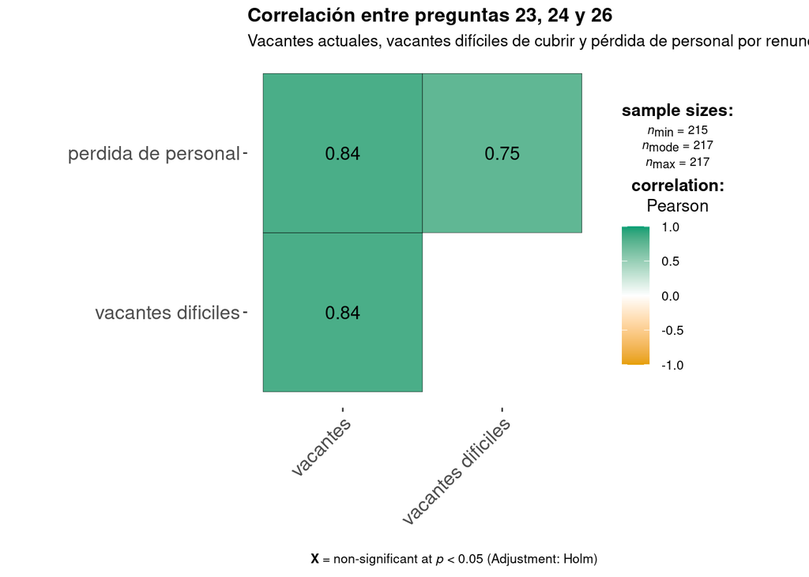

### Relación considerando variables categorizadas

#### Preg 23 vs Preg 24

Frecuencias absolutas

| Tiene vacantes | Vacantes difíciles Sí | Vacantes difíciles No | Total |  |
| --- | --- | --- | --- | --- |
| Sí | 85 | 29 |  | 114 |
| No | 23 | 71 | 94 |  |
| Total | 108 | 100 | 208 |  |

Frecuencias relativas

| Tiene vacantes | Vacantes difíciles Sí | Vacantes difíciles No | Total |  |
| --- | --- | --- | --- | --- |
| Sí | 0.41 | 0.14 |  | 0.55 |
| No | 0.11 | 0.34 | 0.45 |  |
| Total | 0.52 | 0.48 | 1.00 |  |

#### Preg 23 vs Preg 25

Frecuencias absolutas

| Tiene vacantes | Dificultades retención Sí | Dificultades retención No | Total |  |
| --- | --- | --- | --- | --- |
| Sí | 55 | 61 |  | 116 |
| No | 19 | 75 | 94 |  |
| Total | 74 | 136 | 210 |  |

Frecuencias relativas

| Tiene vacantes | Dificultades retención Sí | Dificultades retención No | Total |  |
| --- | --- | --- | --- | --- |
| Sí | 0.26 | 0.29 |  | 0.55 |
| No | 0.09 | 0.36 | 0.45 |  |
| Total | 0.35 | 0.65 | 1.00 |  |

#### Preg 23 vs Preg 26

Frecuencias absolutas

| Tiene vacantes | Renuncias Sí | Renuncias No | Total |  |
| --- | --- | --- | --- | --- |
| Sí | 87 | 29 |  | 116 |
| No | 43 | 50 | 93 |  |
| Total | 130 | 79 | 209 |  |

Frecuencias relativas

| Tiene vacantes | Renuncias Sí | Renuncias No | Total |  |
| --- | --- | --- | --- | --- |
| Sí | 0.42 | 0.14 |  | 0.56 |
| No | 0.21 | 0.24 | 0.45 |  |
| Total | 0.63 | 0.38 | 1.01 |  |

#### Preg 24 vs Preg 25

Frecuencias absolutas

| Vacantes difíciles | Dificultades retención Sí | Dificultades retención No | Total |  |
| --- | --- | --- | --- | --- |
| Sí | 56 | 52 |  | 108 |
| No | 16 | 84 | 100 |  |
| Total | 72 | 136 | 208 |  |

Frecuencias relativas

| Vacantes difíciles | Dificultades retención Sí | Dificultades retención No | Total |  |
| --- | --- | --- | --- | --- |
| Sí | 0.27 | 0.25 |  | 0.52 |
| No | 0.08 | 0.40 | 0.48 |  |
| Total | 0.35 | 0.65 | 1.00 |  |

#### Preg 24 vs Preg 26

Frecuencias absolutas

| Vacantes difíciles | Renuncias Sí | Renuncias No | Total |  |
| --- | --- | --- | --- | --- |
| Sí | 83 | 25 |  | 108 |
| No | 45 | 54 | 99 |  |
| Total | 128 | 79 | 207 |  |

Frecuencias relativas

| Vacantes difíciles | Renuncias Sí | Renuncias No | Total |  |
| --- | --- | --- | --- | --- |
| Sí | 0.40 | 0.12 |  | 0.52 |
| No | 0.22 | 0.26 | 0.48 |  |
| Total | 0.62 | 0.38 | 1.00 |  |

#### Preg 25 vs Preg 26

Frecuencias absolutas

| Dificultades retención | Renuncias Sí | Renuncias No | Total |  |
| --- | --- | --- | --- | --- |
| Sí | 67 | 7 |  | 74 |
| No | 63 | 72 | 135 |  |
| Total | 130 | 79 | 209 |  |

Frecuencias relativas

| Dificultades retención | Renuncias Sí | Renuncias No | Total |  |
| --- | --- | --- | --- | --- |
| Sí | 0.32 | 0.03 |  | 0.35 |
| No | 0.30 | 0.34 | 0.64 |  |
| Total | 0.62 | 0.37 | 0.99 |  |